# EE0848 Machine Learning for SP

Week 6: Decision Trees & Ensembles

Basri Erdogan

## Last Week

Data Preprocessing and Regularization

## Today

- Decision Trees for Classification
- Ensemble Models
- Random Forests

# Decision Trees for Classification

## Why Trees?

- Very powerful, non-parametric, non-linear
- They do not care about scaling
- Basis of very powerful models
- More interpretable

## How Do They Work?

Each node corresponds to a **question** asked about the data.

When we are doing classification we have continuous features and so the questions are **thresholds on single features**.

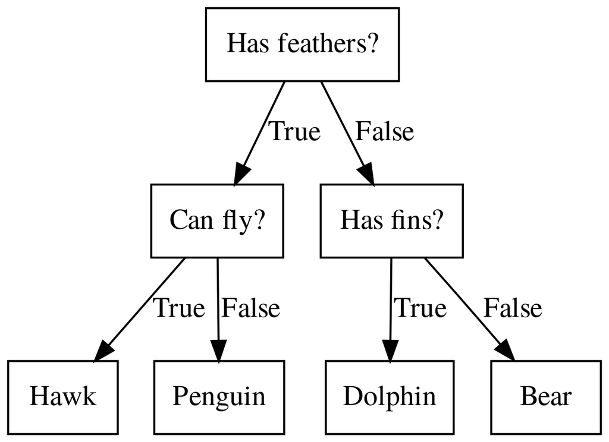

## Criteria (for Classification)

For classification trees, the most common splitting criteria are:

- **Gini Impurity**: Measures the probability of misclassifying a randomly chosen element
  $$\text{Gini}(t) = 1 - \sum_{i=1}^{c} p(i|t)^2$$
- **Entropy / Information Gain**: Measures the disorder or uncertainty
  $$H(t) = -\sum_{i=1}^{c} p(i|t) \log_2 p(i|t)$$

Note: By convention, $0 \cdot \log_2(0) = 0$, since $\lim_{p \to 0^+} p \log_2 p = 0$. A pure node contributes 0 to entropy.

where $p(i|t)$ is the proportion of samples belonging to class $i$ in node $t$, and $c$ is the number of classes.

At each node, the algorithm chooses the feature and threshold that **minimizes the impurity** in the resulting child nodes.

## Step-by-Step Example: The Dataset

| Age | Loves Rock? |
| --- | --- |
| 7 | No |
| 12 | No |
| 18 | Yes |
| 35 | Yes |
| 38 | Yes |
| 50 | No |
| 83 | No |

**7 samples**: 3 Yes, 4 No

**Goal**: Build a decision tree that predicts whether someone loves rock music based on their age.

**How?** At each step, find the **best yes/no question** to split the data into purer groups.

But how do we measure “purity”? We need a way to score each possible split…

*StatQuest with Josh Starmer - Decision and Classification Trees, Clearly Explained!!!*

## Step 1: Measuring Impurity with Gini

**Gini Impurity** measures how “mixed” a group is:

$$\text{Gini}(t) = 1 - \sum_{i=1}^{c} p(i|t)^2$$

**Example** — our root node has 3 Yes, 4 No:

$$\text{Gini} = 1 - \left(\tfrac{3}{7}\right)^2 - \left(\tfrac{4}{7}\right)^2 = 0.490$$

Gini = 0.5 → maximally mixed

Gini = 0 → perfectly pure

**When we split**, we compute the **weighted average** of child Gini values:

$$\text{Gini}_{\text{split}} = \frac{n_L}{n} \cdot \text{Gini}_L + \frac{n_R}{n} \cdot \text{Gini}_R$$

The split that gives the **lowest** weighted Gini wins.

$n$ = total samples in the node, $n_L$ = samples in the left child, $n_R$ = samples in the right child.

## Step 2: Find Candidate Thresholds

Sort by Age and compute **midpoints** between adjacent values — each midpoint is a candidate split:

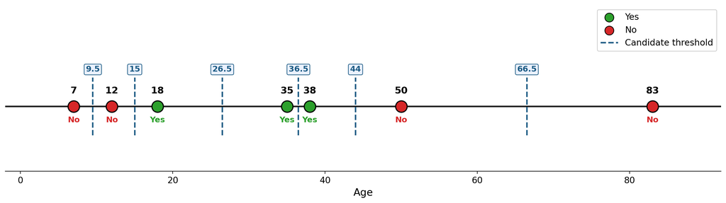

This gives us **6 candidate questions**: *“Age < 9.5?”*, *“Age < 15?”*, *“Age < 26.5?”*, …

We evaluate **every one** and pick the best.

## Step 3: Evaluate Each Split

| Threshold | Left: Yes / No | Right: Yes / No | Weighted Gini |
| --- | --- | --- | --- |
| Age < 9.5 | 0 / 1 | 3 / 3 | 0.429 |
| **Age < 15** | **0 / 2** | **3 / 2** | **0.343** |
| Age < 26.5 | 1 / 2 | 2 / 2 | 0.476 |
| Age < 36.5 | 2 / 2 | 1 / 2 | 0.476 |
| **Age < 44** | **3 / 2** | **0 / 2** | **0.343** |
| Age < 66.5 | 3 / 3 | 0 / 1 | 0.429 |

**Example** — Age < 15: Left = {7,12} all No → Gini = 0. Right = {18,35,38,50,83} 3Y/2N → Gini = 0.48.

$$\text{Weighted Gini} = \tfrac{2}{7} \times 0 + \tfrac{5}{7} \times 0.48 = \mathbf{0.343}$$

**Best split: Age < 15** (lowest weighted Gini, reduces impurity from 0.490 to 0.343)

## Step 4: First Split — Age < 15

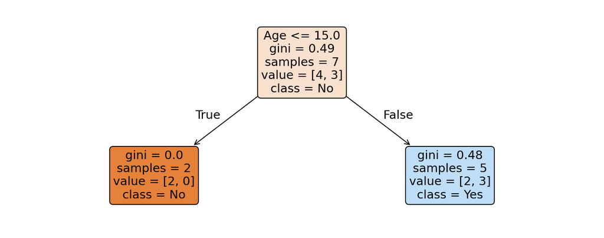

- Left child is **pure** (all “No”) → becomes a **leaf node**
- Right child still mixed → **repeat the process** on this subset

Now evaluate thresholds for the 5 remaining samples {18(Y), 35(Y), 38(Y), 50(N), 83(N)}:

| Threshold | Left: Yes / No | Right: Yes / No | Weighted Gini |
| --- | --- | --- | --- |
| Age < 26.5 | 1 / 0 | 2 / 2 | 0.400 |
| Age < 36.5 | 2 / 0 | 1 / 2 | 0.267 |
| **Age < 44** | **3 / 0** | **0 / 2** | **0.000** |
| Age < 66.5 | 3 / 1 | 0 / 1 | 0.300 |

**Age < 44** gives a **perfect split** (Gini = 0) — both children are pure!

## Step 5: The Final Tree & Prediction

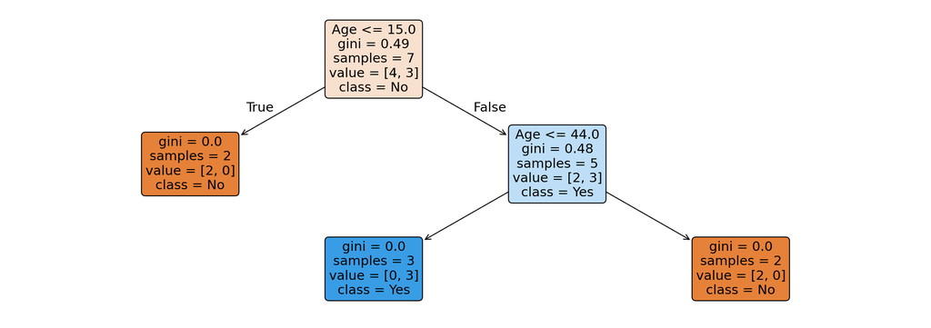

100% accuracy on training data. To predict a **new** sample, traverse root to leaf:

**Example**: Age = 25 → Age < 15? **No** → Age < 44? **Yes** → Predict **“Loves Rock”**

**Example**: Age = 60 → Age < 15? **No** → Age < 44? **No** → Predict **“Doesn’t Love Rock”**

## Building Trees: A More Complex Example

With **multiple features**, the algorithm evaluates thresholds for **every feature** at each node and picks the best overall split.

- “Questions” are thresholds on single features
- Minimize impurity at each split
- Repeat recursively

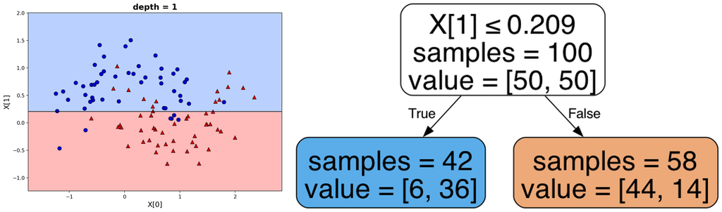

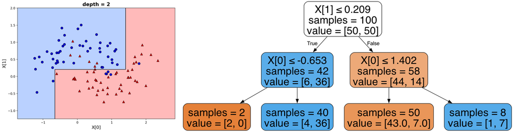

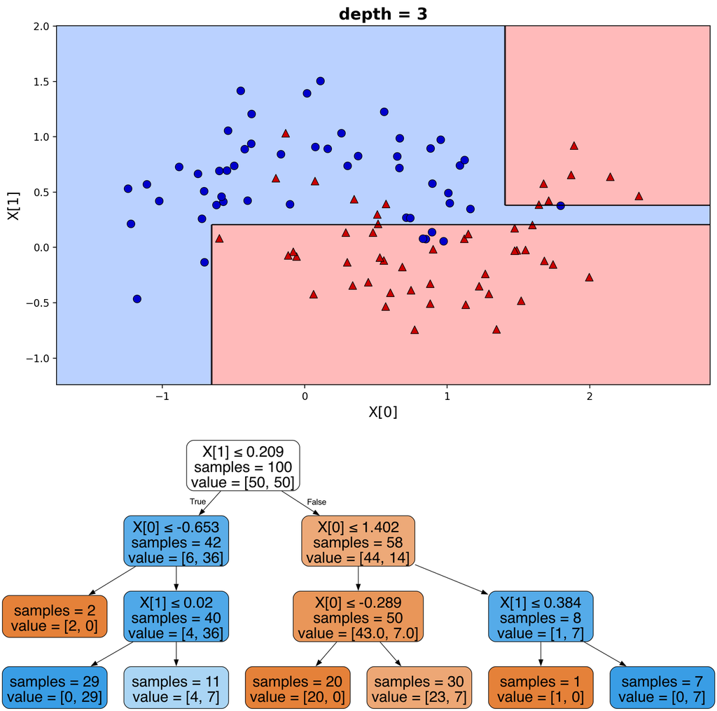

## Regression Trees

*StatQuest with Josh Starmer - Regression Trees, Clearly Explained!!!*

- Prediction is the **mean** of target values in a leaf
- Impurity criterion: **mean squared error**

**Finding splits** — same greedy approach as classification:

1. Sort data by feature, compute **midpoints** as candidate thresholds
2. For each candidate, compute the **weighted MSE** of the two child nodes:
   $$\text{MSE}_{\text{split}} = \frac{n_L}{n} \cdot \text{MSE}_L + \frac{n_R}{n} \cdot \text{MSE}_R$$
3. Pick the threshold with the **lowest** weighted MSE
4. With multiple features, evaluate all thresholds for every feature

**Prediction:** $\;\bar{y}_m = \frac{1}{N_m} \sum_{i \in N_m} y_i$

**MSE:** $\;H(X_m) = \frac{1}{N_m} \sum_{i \in N_m} (y_i - \bar{y}_m)^2$

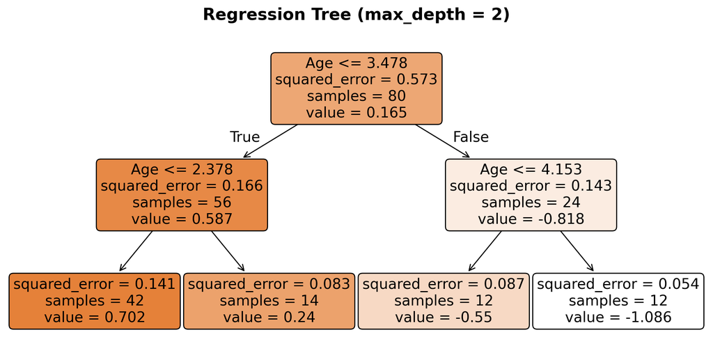

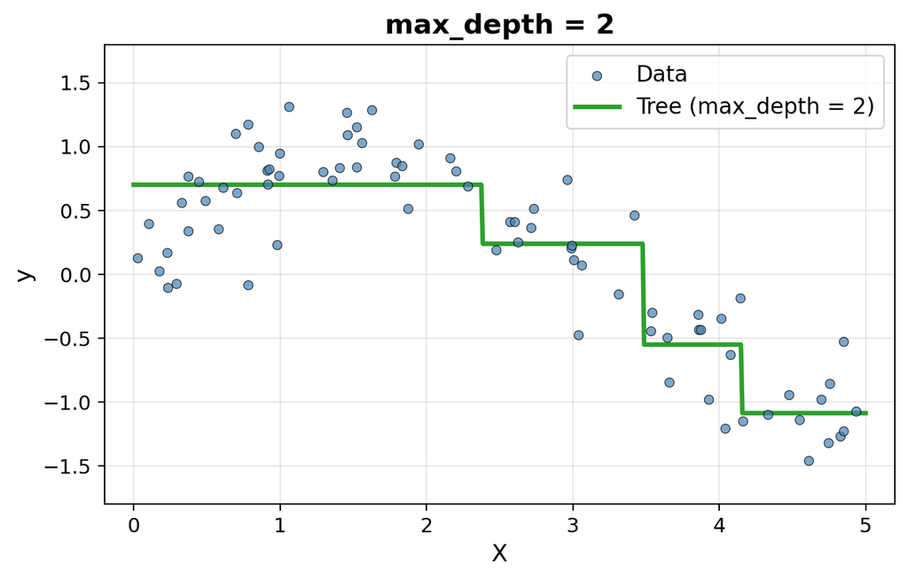

## Regression Trees — Effect of `max_depth`

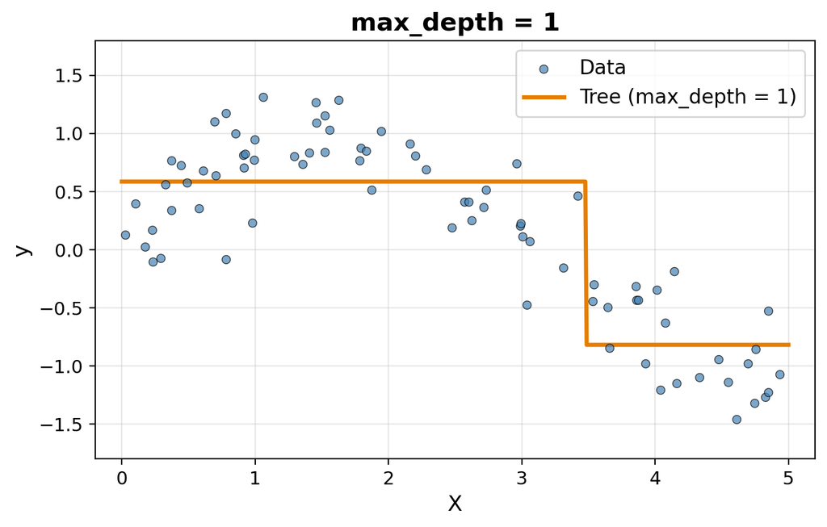

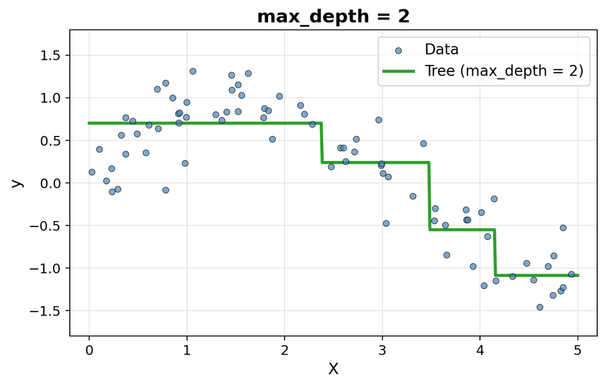

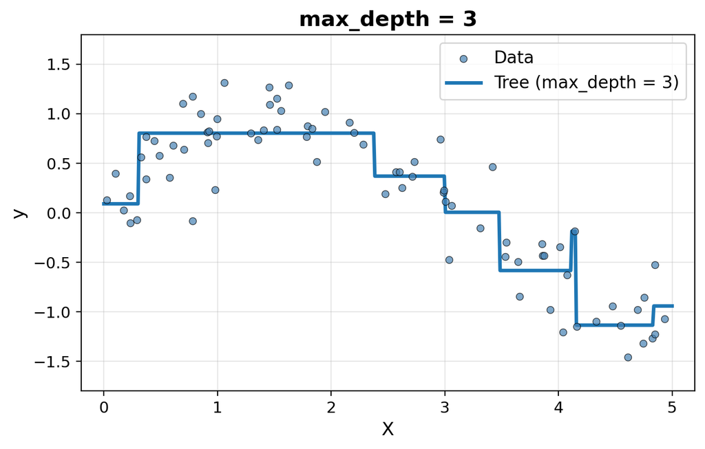

Deeper trees capture more detail but risk **overfitting** — each leaf predicts the mean of fewer samples.

## Regression Trees — Overfitting

Without depth limits, the tree memorizes every training point:

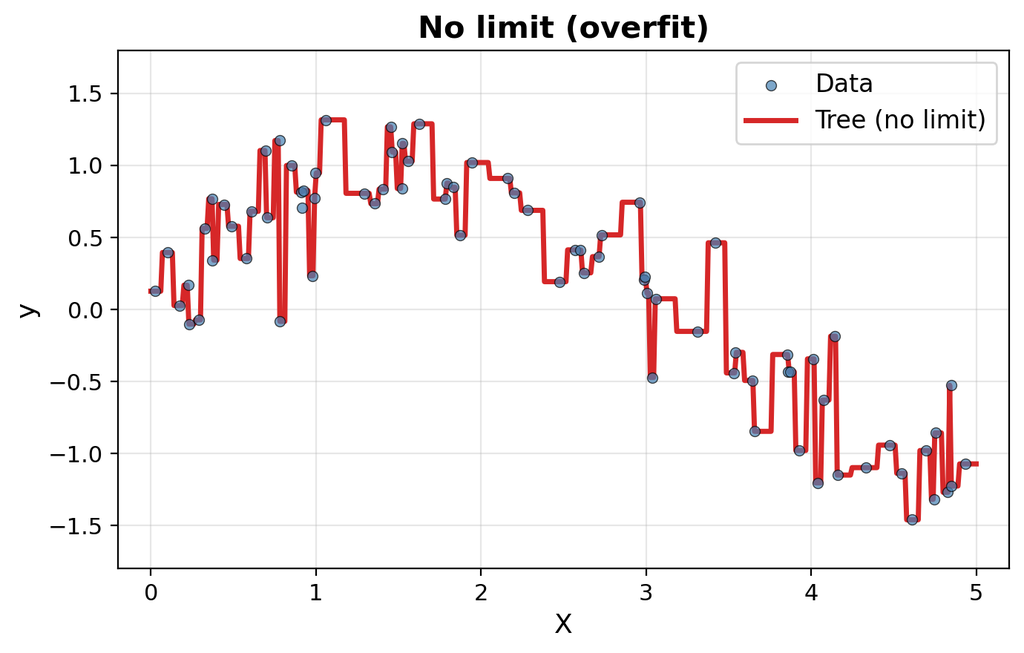

Each leaf contains a single sample — **perfect fit on training data, poor generalization**.

## Wisconsin Diagnostic Breast Cancer (WDBC)

Features are computed from a digitized image of a fine needle aspirate (FNA) of a breast mass. They describe characteristics of the cell nuclei present in the image.

**Data Set Information:**

- Number of instances: 569
- Number of attributes: 32
  1. ID number
  2. Diagnosis (M = malignant, B = benign)
  3. Ten real-valued features computed for each cell nucleus:
     - radius, texture, perimeter, area, smoothness, compactness, concavity, concave points, symmetry, fractal dimension

## Visualizing Trees with sklearn

```python
from sklearn.datasets import load_breast_cancer
cancer = load_breast_cancer()
X_train, X_test, y_train, y_test = train_test_split(cancer.data, cancer.target,
                                                      stratify=cancer.target,
                                                      random_state=0)

from sklearn.tree import DecisionTreeClassifier
tree = DecisionTreeClassifier(max_depth=2)
tree.fit(X_train, y_train)
```

```python
from sklearn.tree import plot_tree
tree_dot = plot_tree(tree, feature_names=cancer.feature_names)
```

## Visualizing Trees with sklearn

[figure not shown]

Color: blue = benign, orange = malignant. Darker shading = higher class purity.

## Hyperparameter Tuning

These are **regularization parameters** — they control model capacity by limiting tree complexity, just like regularization in linear models prevents overfitting.

**Pre-pruning and post-pruning** - Limit tree size (pick one, maybe two):

- `max_depth`
- `max_leaf_nodes`
- `min_samples_split`
- `min_impurity_decrease`

## No Pruning

Breast cancer dataset — full tree without any constraints:

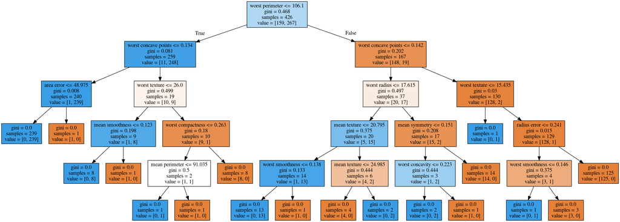

Many leaves contain just 1–2 samples — the tree has memorized the training data including noise.

## `max_depth = 4`

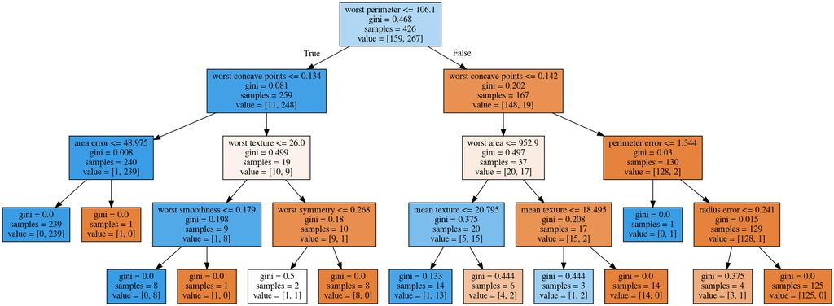

Limits the tree to 4 levels. Captures the most important splits early on while ignoring noisy details deeper in the tree.

## `max_leaf_nodes = 8`

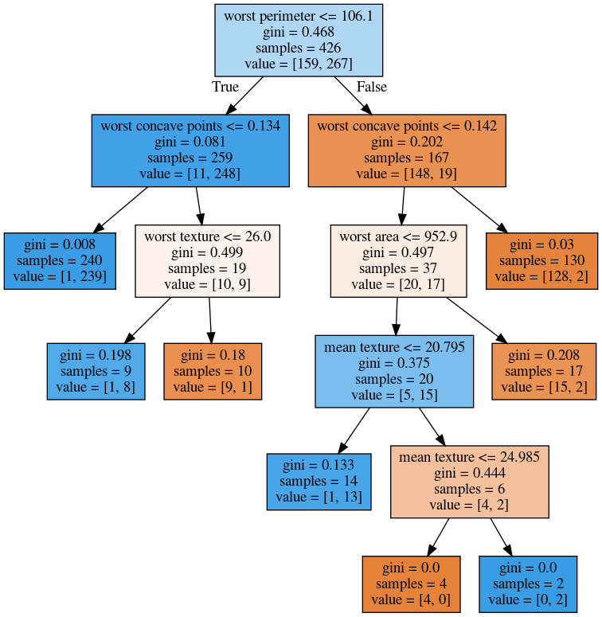

Caps the total number of leaves. The tree can grow deeper on informative branches while keeping overall complexity low.

## `min_samples_split = 50`

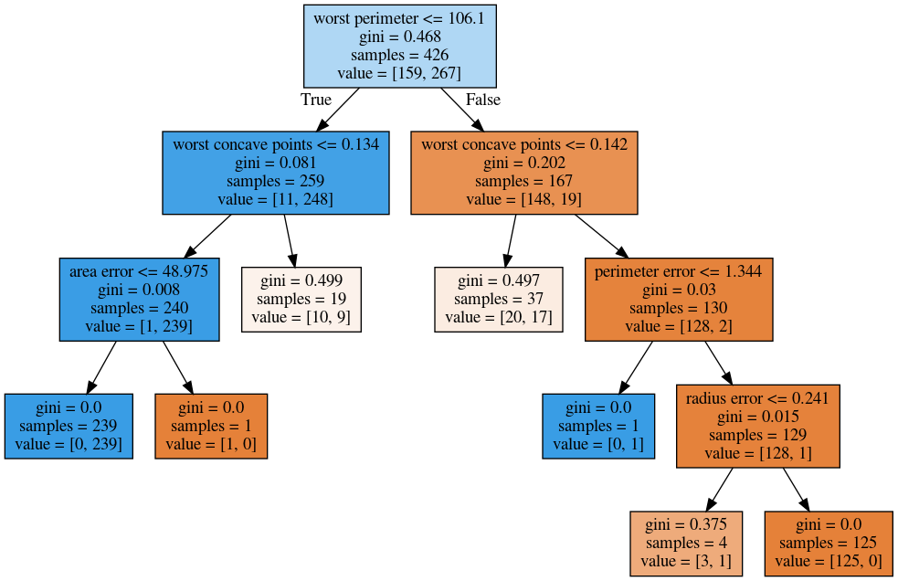

A node must have at least 50 samples to be split further. Prevents the tree from creating leaves based on too few observations.

## Hyperparameter Search (`max_depth`)

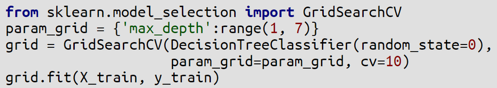

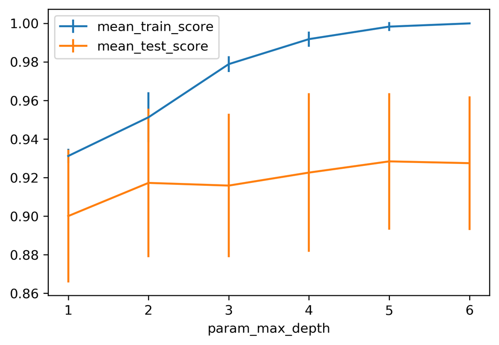

## Hyperparameter Search (`max_leaf_nodes`)

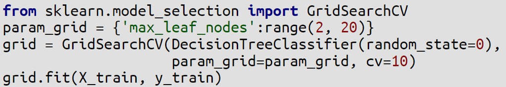

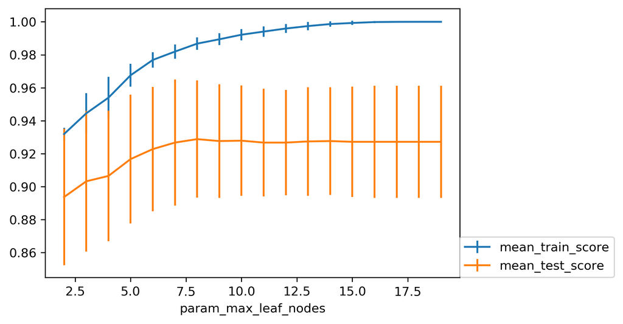

Test accuracy levels off around **7–8 leaf nodes** while training accuracy continues toward 100%. More leaves don’t hurt here, but they don’t help either — prefer the **simplest model** that achieves the best test score.

## Extrapolation

RAM prices in $/Mbyte historically — can a tree predict the future?

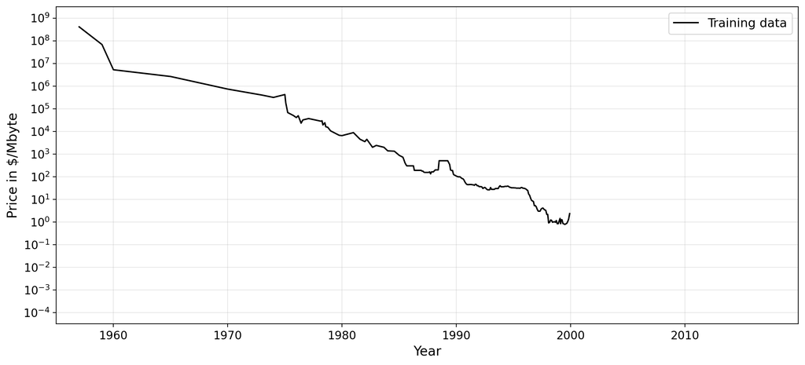

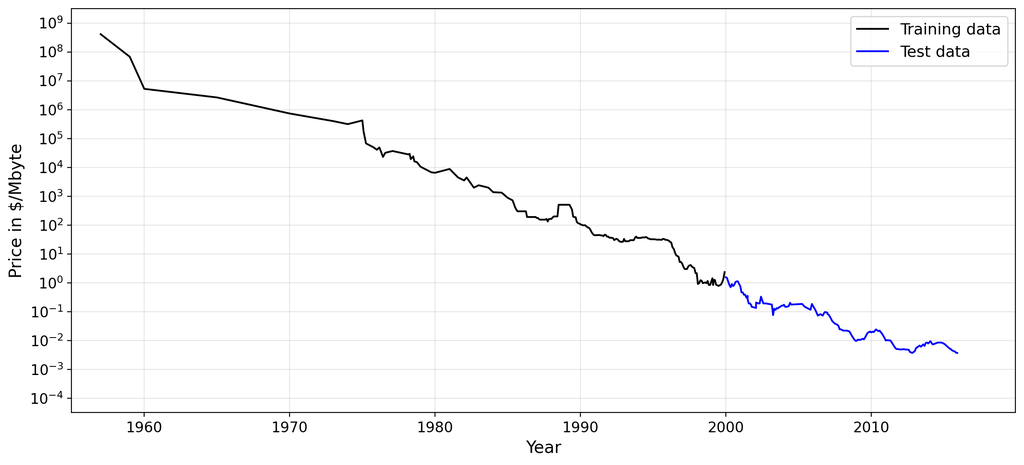

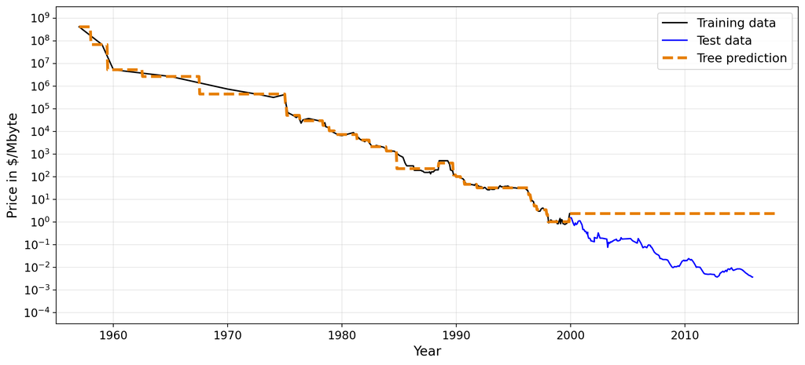

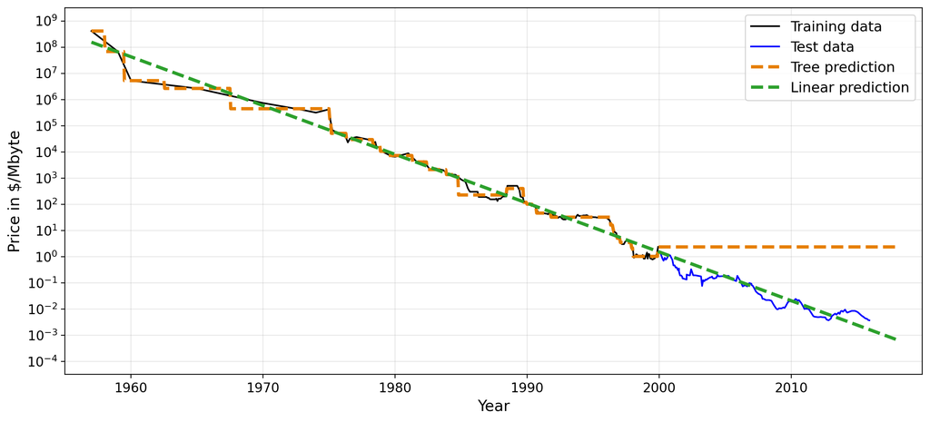

Trees **cannot extrapolate** — they always predict a constant beyond the training range. For trending data, a model that captures the relationship (e.g., linear regression) can project forward.

## Instability

Iris dataset — same model (`max_leaf_nodes=6`), only `random_state` changes:

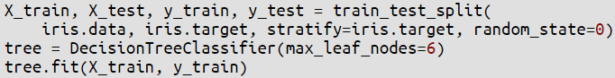

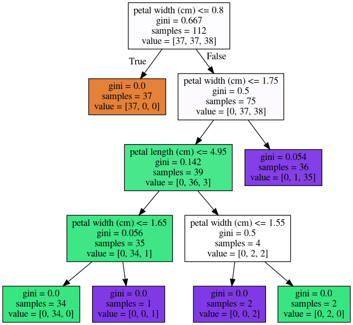

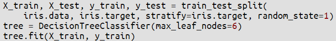

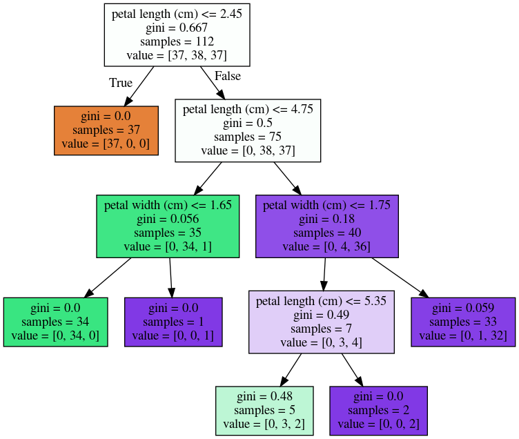

Different train/test splits → **completely different trees**. Small changes in data can lead to entirely different splits — this motivates **ensemble methods**.

## Feature Importance

How often the tree split on a feature and how much that feature decreases the impurity.

```python
X_train, X_test, y_train, y_test = train_test_split(
    iris.data, iris.target, stratify=iris.target, random_state=0)
tree = DecisionTreeClassifier(max_leaf_nodes=6)
tree.fit(X_train, y_train)
```

```python
tree.feature_importances_
```

```
array([0.0, 0.0, 0.414, 0.586])
```

Measures impurity decrease on the **training set**

A single tree is unstable — different train/test splits can produce completely different importance rankings.

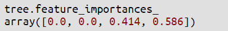

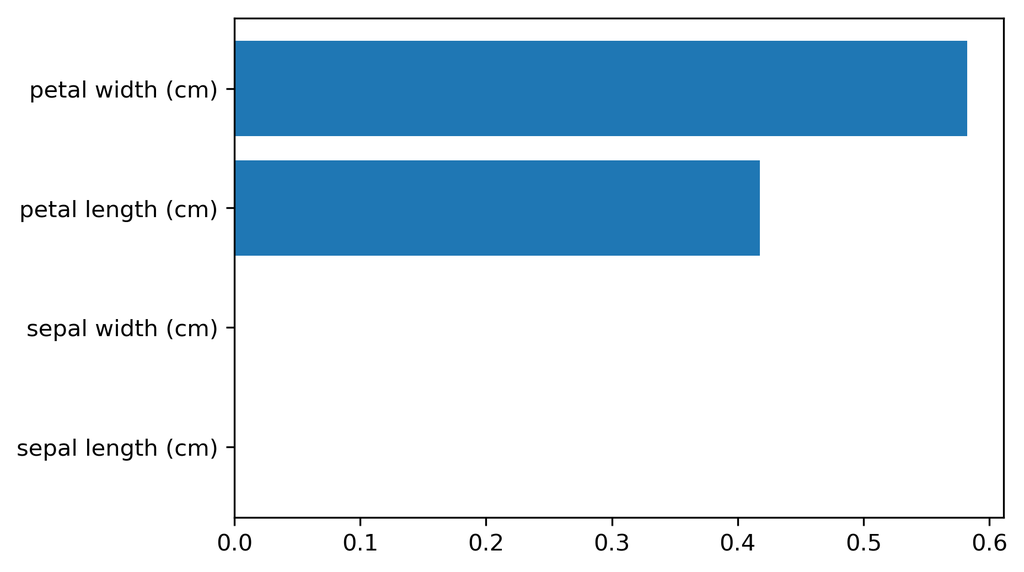